# Life History Relationships

16 febrero, 2017

Quick Start

Methods

Simulation

Estimation

More Information

References

Life history traits include growth rate; age and size at sexual maturity; the temporal pattern or schedule of reproduction; the number, size, and sex ratio of offspring; the distribution of intrinsic or extrinsic mortality rates (e.g., patterns of senescence); and patterns of dormancy and dispersal. These traits contribute directly to age-specific survival and reproductive functions.[^1] The **FLife** package has a variety of methods for modelling life history traits and functional forms for processes for use in fish stock assessment and for conducting Management Strategy Evaluation (MSE).

These relationships have many uses, for example in age-structured population models, functional relationships for these processes allow the calculation of the population growth rate and have been used to to develop priors in stock assesments and to parameterise ecological models.

Back to Top

# Quick Start

This section provide a quick way to get running and overview of what functions are available, their potential use, and where to seek help. More details are given in later sections.

The simplest way to obtain **FLife** is to install it from the `FLR` repository via the R console:

```r
install.packages("FLife", repos = "http://flr-project.org/R")
```

See help(install.packages) for more details.

After installing the **FLife** package, you need to load it

```r
library(FLife)
```

There is an example teleost dataset used for illustration and as a test dataset, alternatively you can load your own data.

```r
data(teleost)
```

The dataset contains life history parameters for a range of bony fish species and families, i.e. von Bertalanffy growth parameters ($L_{\infty}, k, t_0$), length at 50% mature ($L_{50}$), and the length weight relationship ($a, b$).

When loading a new dataset it is always a good idea to run a sanity check e.g.

```r
is(teleost)
```

```
[1] "FLPar"     "array"     "structure" "vector"
```

The `teleost` object can be used to create `vectors` or other `objects with values by age using **FLife** methods, e.g. to construct a growth curve for hutchen (*Hucho hucho*)

```r
vonB(1:10,teleost[,"Hucho hucho"])
```

```
 [1]  29.0  40.8  51.5  61.1  69.9  77.8  84.9  91.4  97.3 102.6
```

### Plotting

Plotting is done using **ggplot2** which provides a powerful alternative paradigm for creating both simple and complex plots in R using the *Grammar of Graphics*[^2] The idea of the grammar is to specify the individual building blocks of a plot and then to combine them to create the desired graphic[^3].

The **ggplot** methods expects a `data.frame` for its first argument, `data` (this has been overloaded by **ggplotFL** to also accept FLR objects); then a geometric object `geom` that specifies the actual marks put on to a plot and an aesthetic that is “something you can see” have to be provided. Examples of geometic Objects (geom) include points (geom_point, for scatter plots, dot plots, etc), lines (geom_line, for time series, trend lines, etc) and boxplot (geom_boxplot, for, well, boxplots!). Aesthetic mappings are set with the aes() function and, examples include, position (i.e., on the x and y axes), color (“outside” color), fill (“inside” color), shape (of points), linetype and size.

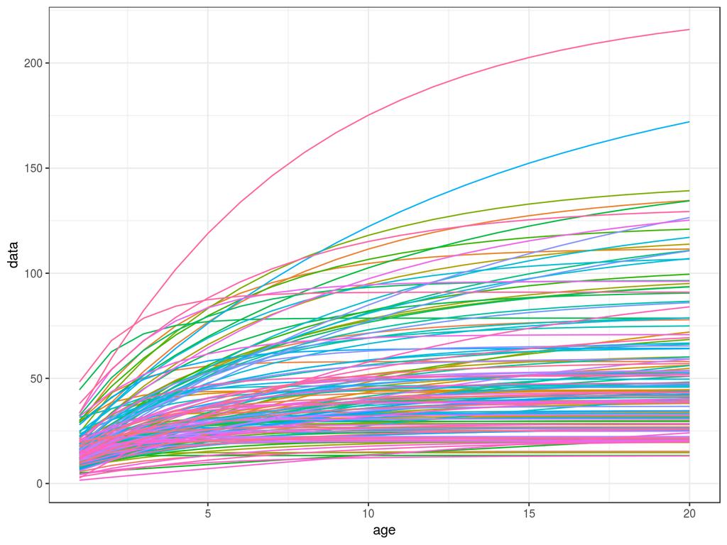

Von Bertalanffy growth curves.

```r
age=FLQuant(1:20,dimnames=list(age=1:20))
len=vonB(age,teleost)

ggplot(as.data.frame(len))+
  geom_line(aes(age,data,col=iter))+
  theme(legend.position="none")
```

Back to Top

# Methods

There are relationships between the life history parameters and size, growth, maturation, natural mortality and productivity, as seen in the following.

## Function Forms

These methods are used to create FLQuants

### Growth

gascuel, gompertz, richards, vonB

### Ogives

dnormal, knife, logistic, sigmoid

### Natural Mortality

gislason, lorenzen

### Conversions

len2wt, wt2len, ages

## Population dynamics

### Ecological

leslie, r

### Simulation

lhPar, lhEql

### Reference points

lopt, loptAge

### Density Dependence

matdd, mdd

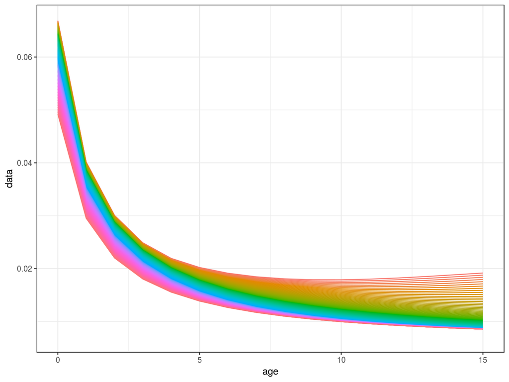

Density Dependence in M

```r
library(FLBRP)

par=teleost[,"Hucho hucho"]
par=lhPar(par)
hutchen=lhEql(par)

scale=stock.n(hutchen)[,25]%*%stock.wt(hutchen)
scale=(stock.n(hutchen)%*%stock.wt(hutchen)%-%scale)%/%scale

m=mdd(stock.wt(hutchen),par=FLPar(m1=.2,m2=-0.288),scale,k=.5)

ggplot(as.data.frame(m))+
   geom_line(aes(age,data,col=factor(year)))+
   theme(legend.position="none")+
    scale_x_continuous(limits=c(0,15))
```

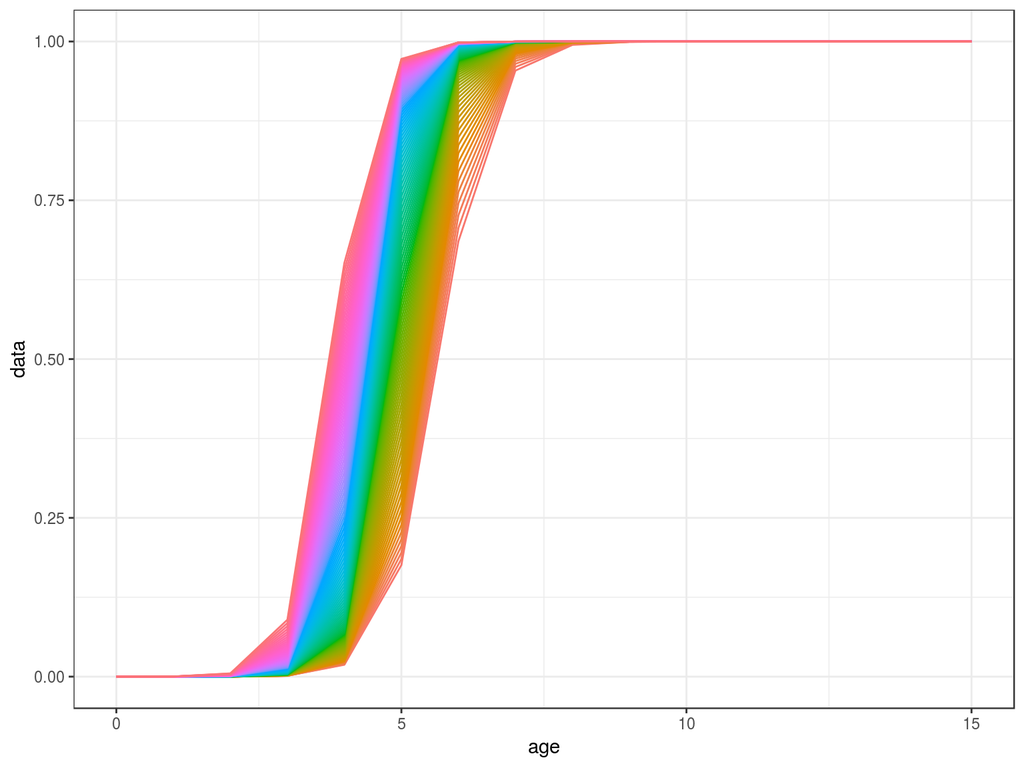

```r
scale=stock.n(hutchen)[,25]%*%stock.wt(hutchen)
scale=(stock.n(hutchen)%*%stock.wt(hutchen)%-%scale)%/%scale

mat=matdd(ages(scale),par,scale,k=.5)

ggplot(as.data.frame(mat))+
    geom_line(aes(age,data,col=factor(year)))+
    theme(legend.position="none")+
    scale_x_continuous(limits=c(0,15))
```

### Parameter estination

moment, powh

### Stationarity

rod

### Random variables

rnoise

## Life History Parameters

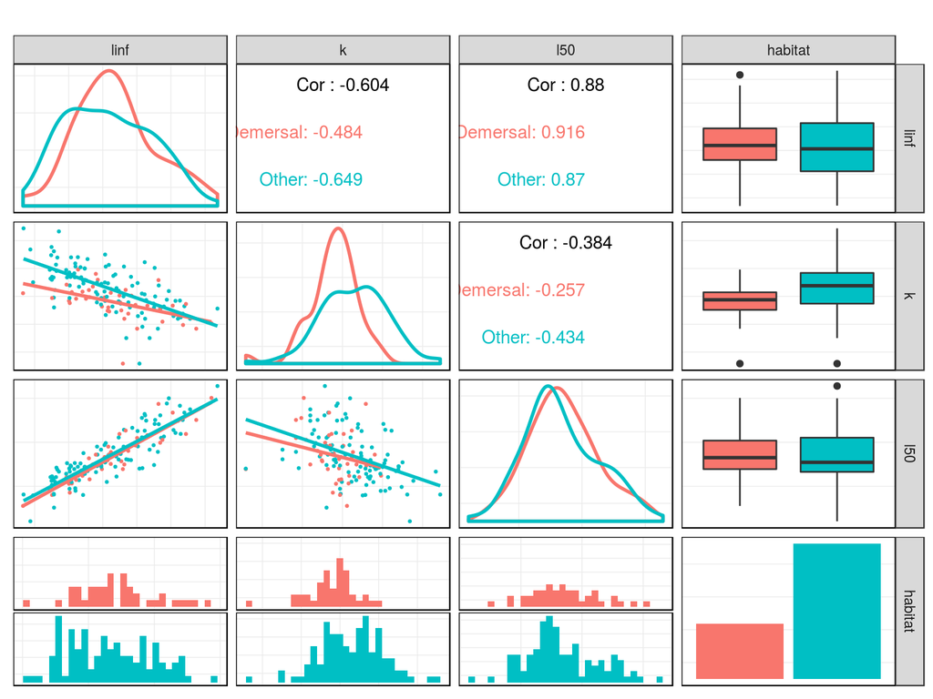

Relationship between life history traits

At a given length a large species will grow faster than a small species, for example consider the von Bertalanffy growth equation

$$L_t = L_\infty (1 - e^{(-kt-t_0)})$$

where $L_\infty$ is the asymptotic maximum length, $k$ is the growth coefficient, $L_t$ is length at time t, and $t_0$ the time at which an individual would, if it possible, be zero length. There is also an empirical relationship between $t_0$ and $L_{\infty}$ and $k$ i.e.

$$log(-t_0) = -0.3922 - 0.2752 log(L_{\infty}) - 1.038 log(k)$$

Therefore for a value of $L_{\infty}$ or even $L_{max}$ the maximum size observered as $L_{\infty} ~ 0.95L_{max}$, all the growth parameters can be recovered.

For larger species securing sufficient food to maintain a fast growth rate may entail exposure to a higher natural mortality (M). In addition, many small demersal species seem to be partly protected against predation by hiding, cryptic behaviour, being flat or by possessing spines. In their analyses of empirical estimates of natural mortality of fish, Griffiths and Harrod (2007) found species that were cryptic, hid in burrows, or had morphological defences against predators to have the lowest rates of natural mortality. Hence, at a given length individuals belonging to species with a high $L_{\infty}$ may generally be exposed to a higher M than individuals belonging to species with a low $L_{\infty}$.

$$log(M) = 0.55-1.61log(L) + 1.44log(L_{\infty}) + log(k)$$
## Functional forms

There are methods for creating growth curves, maturity ogives, natural mortality vectors and selection patterns.

Generation of missing life history relationships

```r
par=lhPar(FLPar(linf=100))
par
```

```
An object of class "FLPar"
params
      linf          k         t0          a          b      ato95
 100.00000    0.16531   -0.10000    0.00030    3.00000    1.00000
       a50       asym         bg         m1         m2         a1
   4.35996    1.00000    3.00000  217.35644   -1.61000    4.35996
        sl         sr          s          v
   2.00000 5000.00000    0.90000 1000.00000
units:  NA NA NA NA NA NA NA NA NA NA NA NA NA NA NA NA
```

## Simulation of equilibrium values and reference points

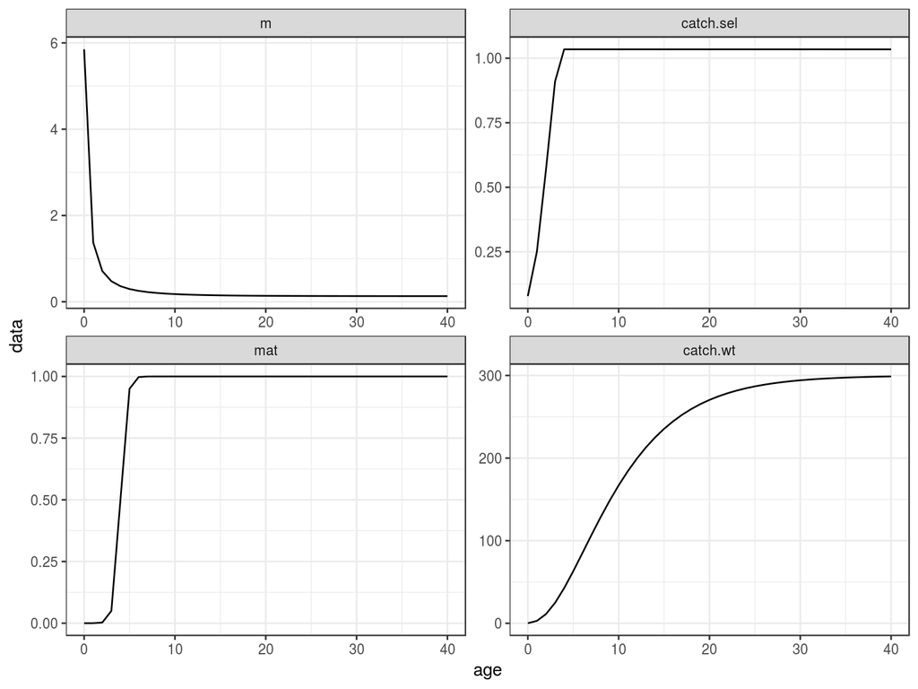

Age-vectors of growthm natural mortality, maturity and selection pattern

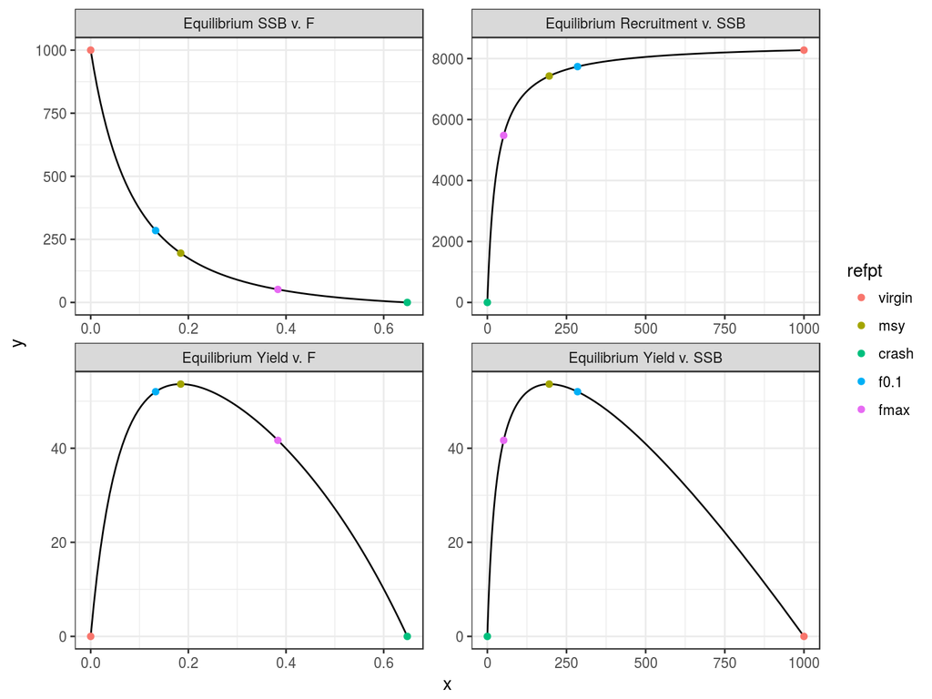

Equilibrium curves and reference points.

```
An object of class "FLPar"
params
        r        rc       msy      lopt        sk      spr0    sprmsy
 0.394344  0.139678 53.644110 63.520418  0.195428  0.120826  0.026313
units:  NA NA NA NA NA NA NA
```

```r
library(FLBRP)
eql=lhEql(par)

ggplot(FLQuants(eql,"m","catch.sel","mat","catch.wt"))+
  geom_line(aes(age,data))+
  facet_wrap(~qname,scale="free")
```

# Simulation

Creation of FLBRP objects

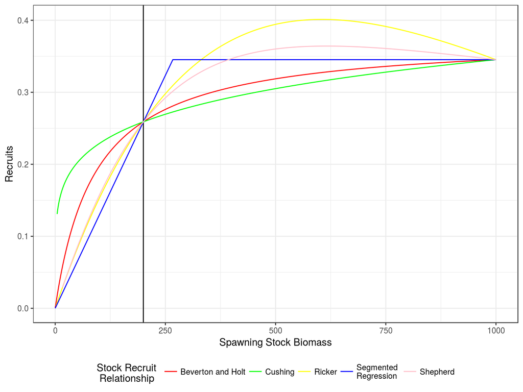

Stock recruitment relationships for a steepness of 0.75 and vigin biomass of 1000

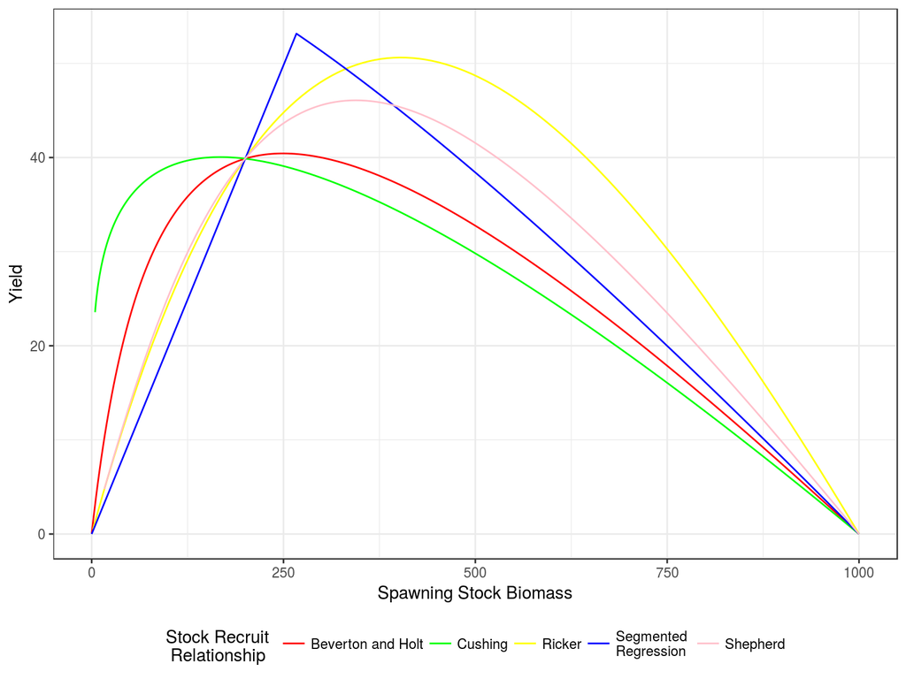

Production curves, Yield v SSB, for a steepness of 0.75 and vigin biomass of 1000.

## Density Dependence

Modelling density dependence in natural mortality and fecundity.

## Noise

Methods to simulate random noise with autocorrelation, e.g. by age or cohort

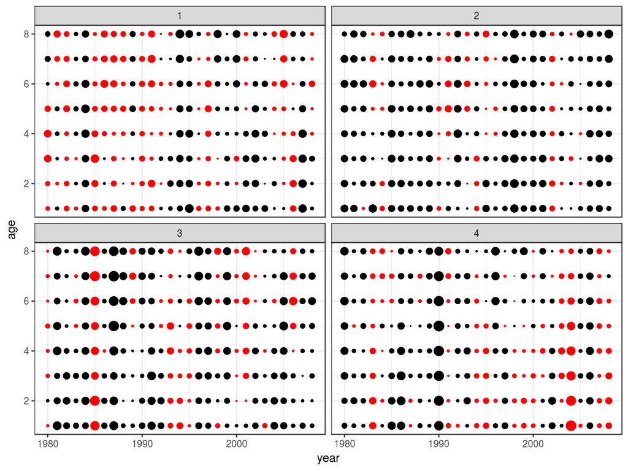

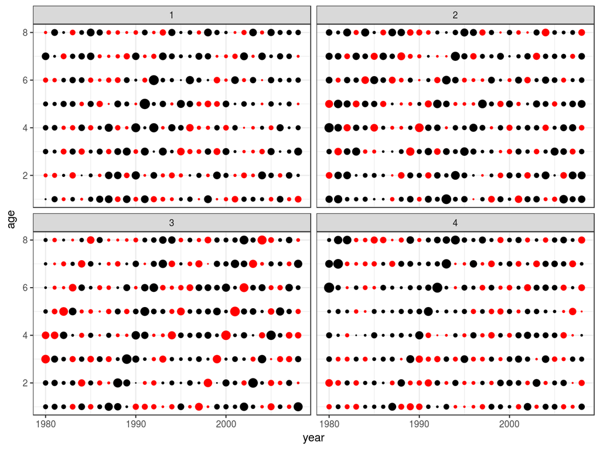

## MSE using empirical HCR

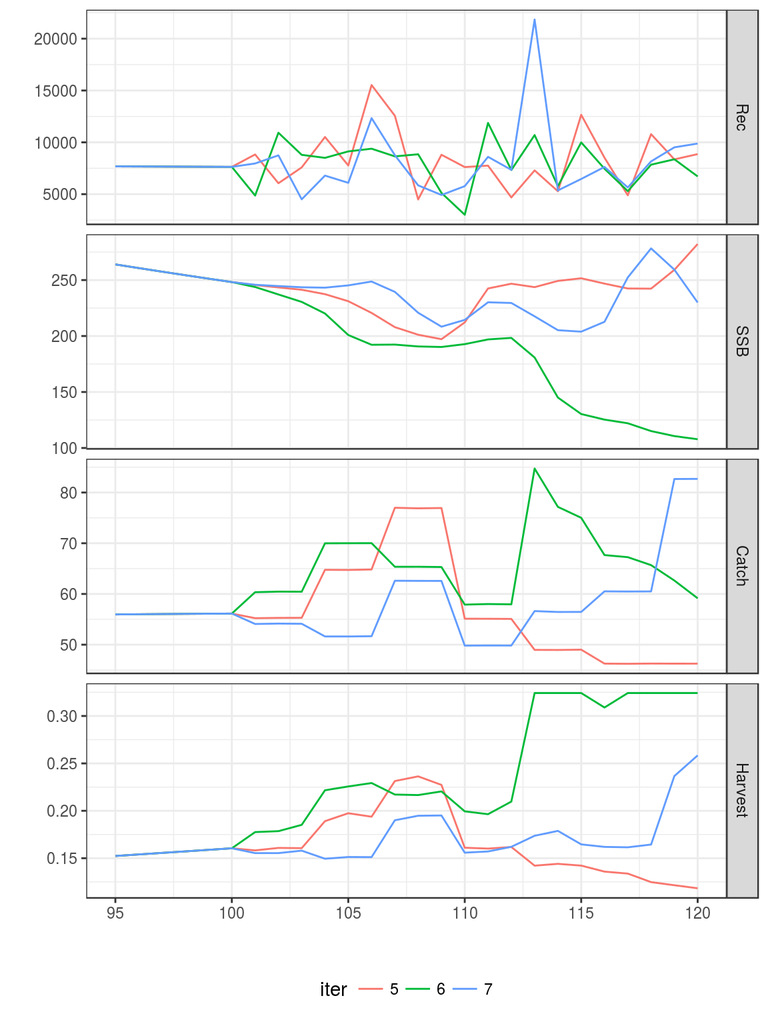

MSE using empirical HCR

Back to Top

# Estimation

Life history parameters can also be used to estimate quantities of use in stock assessment

Beverton and Holt (1956) developed a method to estimate life history and population parameters length data. e.g.

$$\begin{equation}Z=K\frac{L_{\infty}-\overline{L}}{\overline{L}-L^\prime} \end{equation}$$

Based on which Powell (1979) developed a method, extended by Wetherall, Polovina, and Ralston (1987), to estimate growth and mortality parameters. This assumes that the right hand tail of a length frequency distribution was determined by the asymptotic length $L_{\infty}$ and the ratio between Z and the growth rate k.

$$\begin{equation}\overline{L}-L^\prime=a+bL^{\prime} \end{equation}$$
a and b can be estimated by a regression analysis where
$$\begin{equation}b=\frac{-K}{Z+K} \end{equation}$$
$$\begin{equation}a=-bL_{\infty} \end{equation}$$

Therefore plotting $\overline{L}-L^\prime$ against $L^\prime$ therefore provides an estimate of $L_{\infty}$ and Z/K

[output not shown]

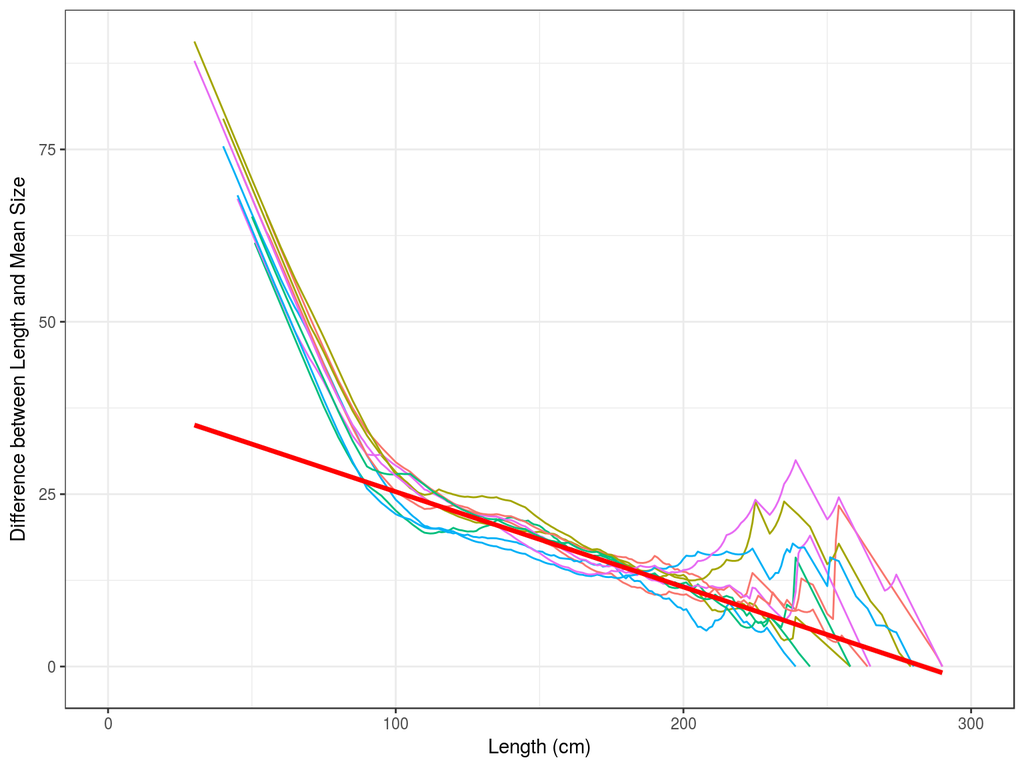

### Catch curve analysis

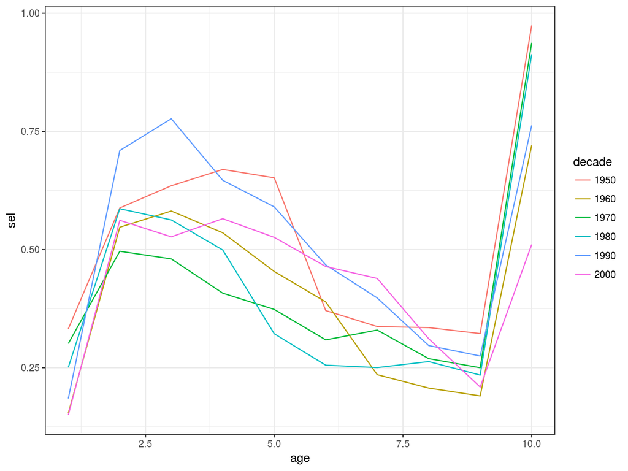

```r
data(ple4)
ctc=as.data.frame(catch.n(ple4))
ctc=ddply(ctc,.(year), with, cc(age=age,n=data))
ctc=ddply(transform(ctc,decade=factor(10*(year%/%10))),.(decade,age),with,data.frame(sel=mean(sel)))
ggplot(ctc)+
  geom_line(aes(age,sel,colour=decade))
```

Back to Top

# More Information

- You can submit bug reports, questions or suggestions on `FLife` at the `FLife` issue page,[^4] or on the *FLR* mailing list.
- Or send a pull request to https://github.com/lauriekell/FLife/
- For more information on the FLR Project for Quantitative Fisheries Science in R, visit the FLR webpage.[^5]
- The latest version of `FLife` can always be installed using the `devtools` package, by calling

```r
    library(devtools)
    install_github("lauriekell/FLife")
```

## Software Versions

- R version 3.3.2 (2016-10-31)
- FLCore: 2.6.0.20160707
- FLife: 2.1.1
- **Compiled**: Thu Feb 16 17:52:17 2017
- **Git Hash**: 4826d3b

## Author information

**Laurence KELL**. laurie@kell.es

# References

Back to Top

Beverton, R.J.H., and S.J. Holt. 1956. “Review of Method for Estimating Mortality Rates in Exploited Fish Populations, with Special Reference to Sources of Bias in Catch Sampling.” *Rapports et Proces-Verbaux.* 140 (1): 67–83.

Powell, David G. 1979. “Estimation of Mortality and Growth Parameters from the Length Frequency of a Catch [Model].” *Rapports et Proces-Verbaux Des Reunions* 175.

Wetherall, JA, JJ Polovina, and S. Ralston. 1987. “Estimating Growth and Mortality in Steady-State Fish Stocks from Length-Frequency Data.” *ICLARM Conf. Proc*, 53–74.

[^1]: http://www.oxfordbibliographies.com/view/document/obo-9780199830060/obo-9780199830060-0016.xml
[^2]: Wilkinson, L. 1999. *The Grammar of Graphics*, Springer. [doi 10.1007/978-3-642-21551-3_13](http://dx.doi.org/10.1007/978-3-642-21551-3_13).
[^3]: http://tutorials.iq.harvard.edu/R/Rgraphics/Rgraphics.html
[^4]: https://github.com/lauriekell/FLife/issues
[^5]: http://flr-project.org